# 17. Sunn Pest (*Eurygaster integriceps*)

Published

October 29, 2026

Download SUNP report as PDF

## **17A. Introduction**

The Sunn pest (SUNP), *Eurygaster integriceps* Puton, 1881 (Hemiptera: Scutelleridae), is a serious and economically important pest of wheat, barley, oats, rye, and sorghum. Its geographic range spans latitudes 25° to 55° N across Eurasia, including much of Eastern Europe, West Asia, Central Asia, and North Africa (Paulian and Popov 1980, Critchley 1998, Mackesy and Moylett 2018, EPPO 2021). Both larvae and adults damage host plants by causing plant death, arresting grain development, or degrading the gluten content of surviving wheat kernels (Paulian and Popov 1980, Critchley 1998). As a result, flour produced from infested grain yields bread of poor quality and reduced digestibility (Paulian and Popov 1980). In the absence of effective control measures, infestations can lead to complete crop loss (Kivan and Kilic 2005). If introduced to the United States, SUNP could cause substantial economic damage to wheat and barley production, which were valued at $7.9 billion and $685 million, respectively, in 2017 (USDA-NASS 2019). Areas at most risk for establishment of SUNP based on host presence are in the Midwestern United States, the Columbia River valley, and the lower Mississippi River valley (Macksey and Moylett 2018).

SUNP is a univoltine pest with two major periods in its annual life cycle (Davari and Parker 2018). Adults spend late summer through winter in aestivation and overwintering sites, where they undergo obligatory diapause and remain largely inactive until spring temperatures reach approximately 10–14 °C, triggering emergence and migration to cereal fields for reproduction (Banks et al. 1961, Critchley 1998, Parker et al. 2011, Islamoglu 2022). Following development through five nymphal instars and the subsequent adult emergence, adults migrate approximately 10–20 km to hillside aestivation and overwintering sites, which occur at higher elevations under bushes in the southern part of the range and in deciduous Quercus forests in the northern part (Paulian and Popov 1980, Critchley 1998, Davari and Parker 2018). This seasonal movement between agricultural and non-crop habitats complicates management and requires appropriately timed monitoring and control (Critchley 1998, Davari and Parker 2018), while regional geographic features that influence temperature can affect the timing and direction of migration (Parker et al. 2011, Islamoglu 2022). Potentially suitable environmental conditions for SUNP occur across most of the contiguous United States (CONUS), although mountainous and higher-latitude regions of the West may be unsuitable for development because of insufficient thermal accumulation (Aljaryian et al. 2016, Barker and Coop 2020). Nevertheless, the species’ migratory behavior could allow adults to move between suitable cereal-growing areas and nearby seasonal aestivation or overwintering sites, potentially facilitating persistence where seasonal conditions limit activity.

## **17B. Results**

### **i. Phenology**

#### **Entire period: 1981–2025**

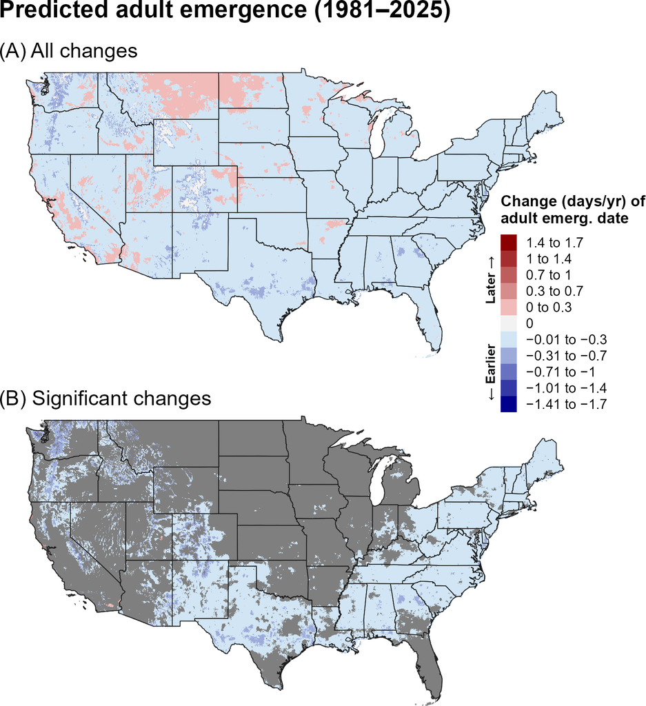

Figure 1: Changes (days/year) in predicted dates of first adult emergence for SUNP across the CONUS over the entire 44-year period (1981–2025). Maps show (A) all changes and (B) statistically significant changes (P < 0.1); areas shown in gray are not statistically significant.

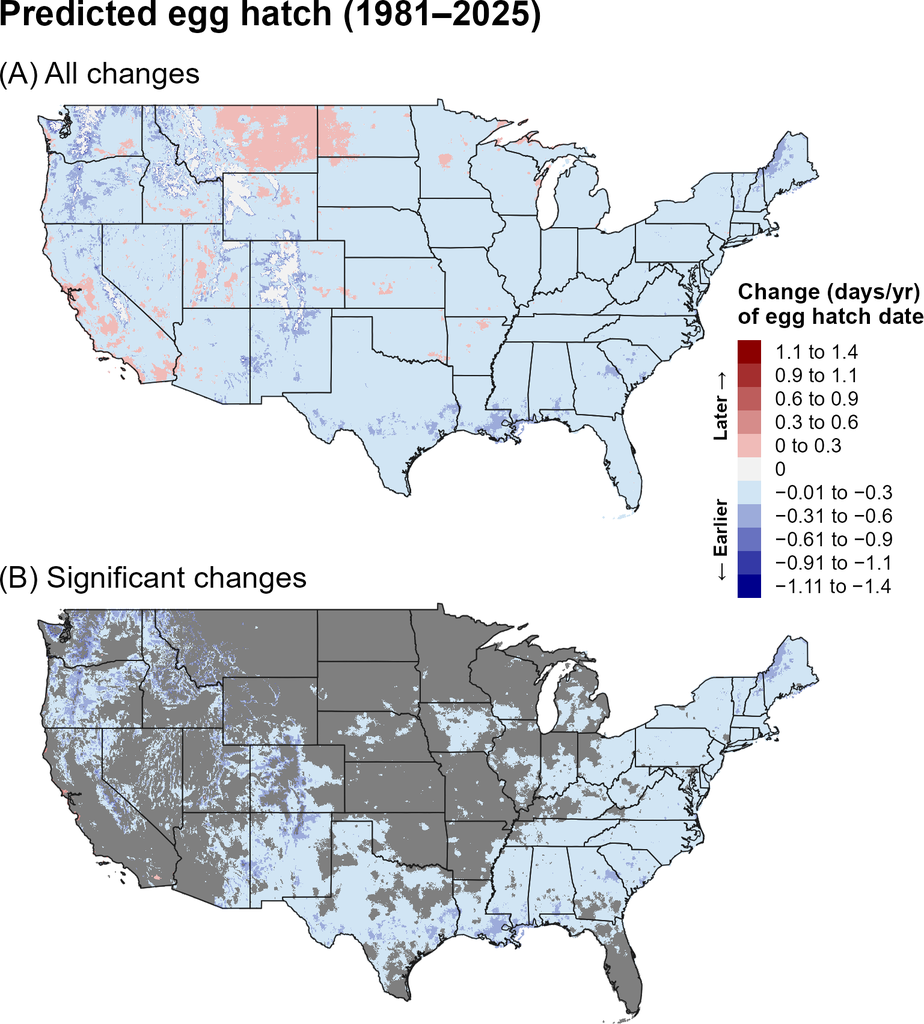

Figure 2: Changes (days/year) in predicted dates of first egg hatch for SUNP across the CONUS over the entire 44-year period (1981–2025). Maps show (A) all changes and (B) statistically significant changes (P < 0.1); areas shown in gray are not statistically significant.

#### **Recent period: 2001–2025**

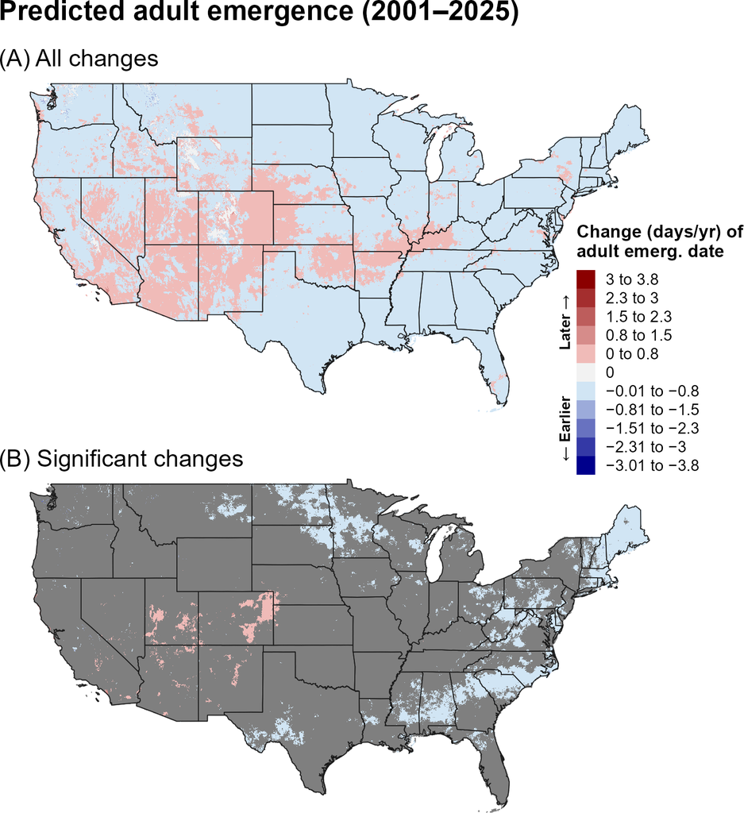

Figure 3: Changes (days/year) in predicted dates of first adult emergence for SUNP across the CONUS over the recent 24-year period (2001–2025). Maps show (A) all changes and (B) statistically significant changes (P < 0.1); areas shown in gray are not statistically significant.

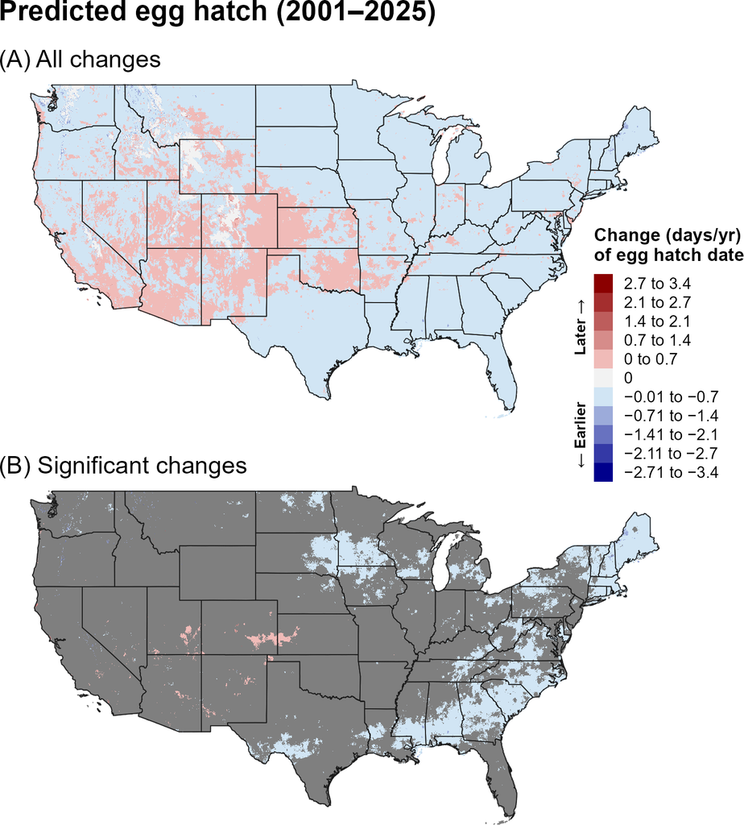

Figure 4: Changes (days/year) in predicted dates of first egg hatch for SUNP across the CONUS over the recent 24-year period (2001–2025). Maps show (A) all changes and (B) statistically significant changes (P < 0.1); areas shown in gray are not statistically significant.

### **ii. Climatic suitability**

#### **Entire period: 1981–2025**

Predicted cold stress decreased across portions of the northern United States over 1981–2025, especially in the northern Plains and Great Lakes, while heat stress increased in the Southwest and southern Great Plains (Figure 5, Figure 6). Climatic suitability increased significantly in portions of the northern Plains and Great Lakes (Figure 7).

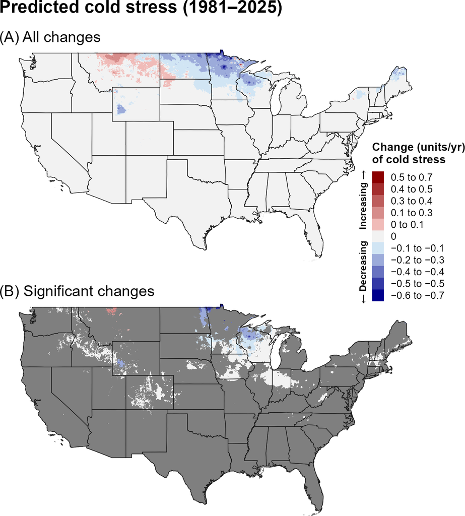

Figure 5: Changes (units/year) in predicted cold stress for SUNP across the CONUS over the entire 44-year period (1981–2025). Maps show (A) all changes and (B) statistically significant changes (P < 0.1); areas shown in gray are not statistically significant. Areas shown as 0 in (B) had significant trends but very small changes.

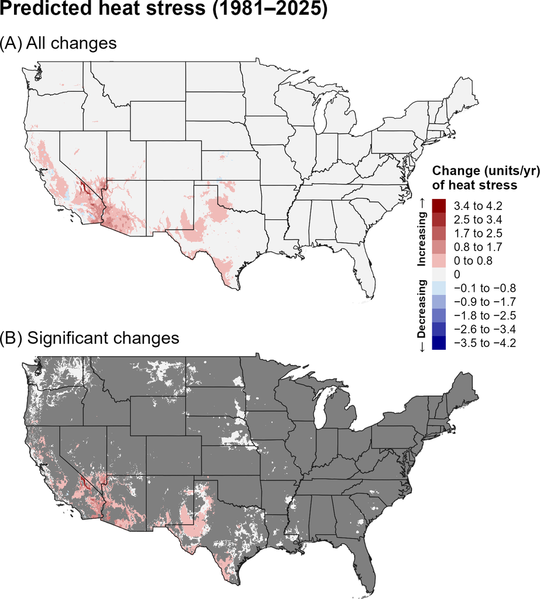

Figure 6: Changes (units/year) in predicted heat stress for SUNP across the CONUS over the entire 44-year period (1981–2025). Maps show (A) all changes and (B) statistically significant changes (P < 0.1); areas shown in gray are not statistically significant. Areas shown as 0 in (B) had significant trends but very small changes.

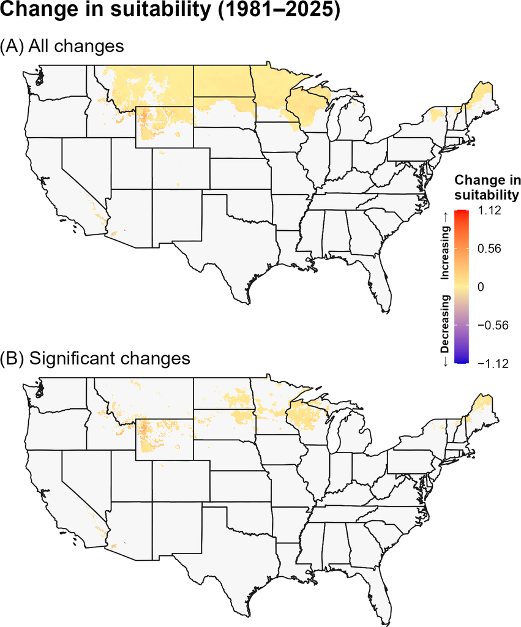

Figure 7: Changes in predicted climatic suitability for SUNP across the CONUS over the 44-year period (1981–2025). Suitability is defined as areas not excluded by climate stress. Positive changes (warmer colors) indicate an increased likelihood of establishment, whereas negative changes (cooler colors) indicate a decreased likelihood of establishment.

#### **Recent period: 2001–2025**

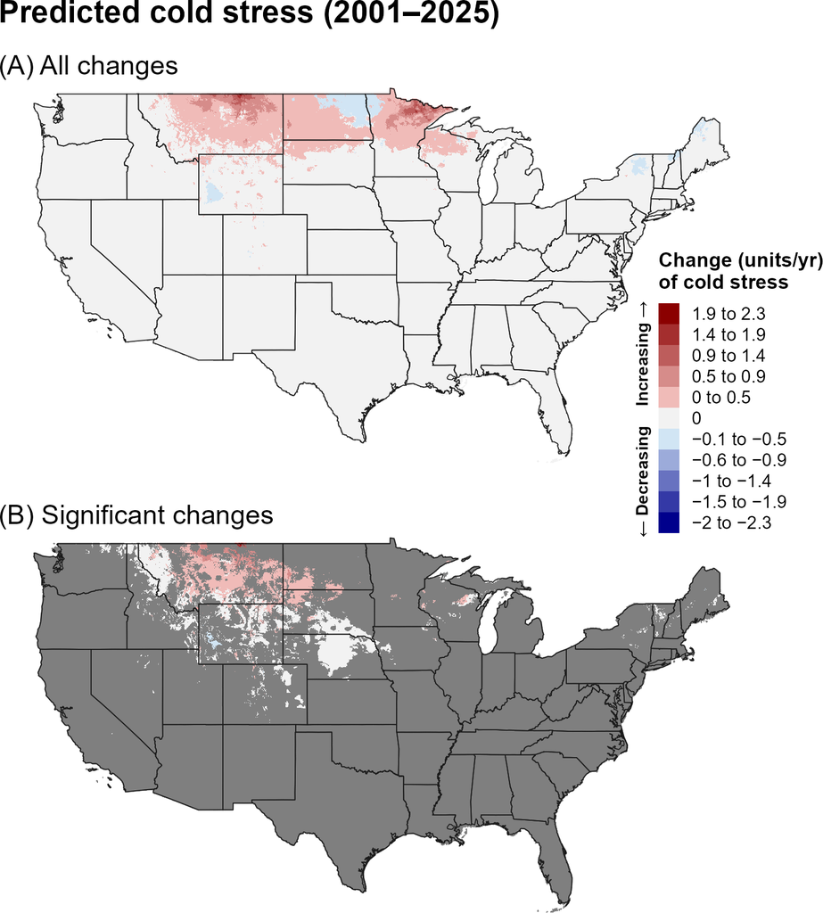

Figure 8: Changes (units/year) in predicted cold stress for SUNP across the CONUS over the recent 24-year period (2001–2025). Maps show (A) all changes and (B) statistically significant changes (P < 0.1); areas shown in gray are not statistically significant. Areas shown as 0 in (B) had significant trends but very small changes.

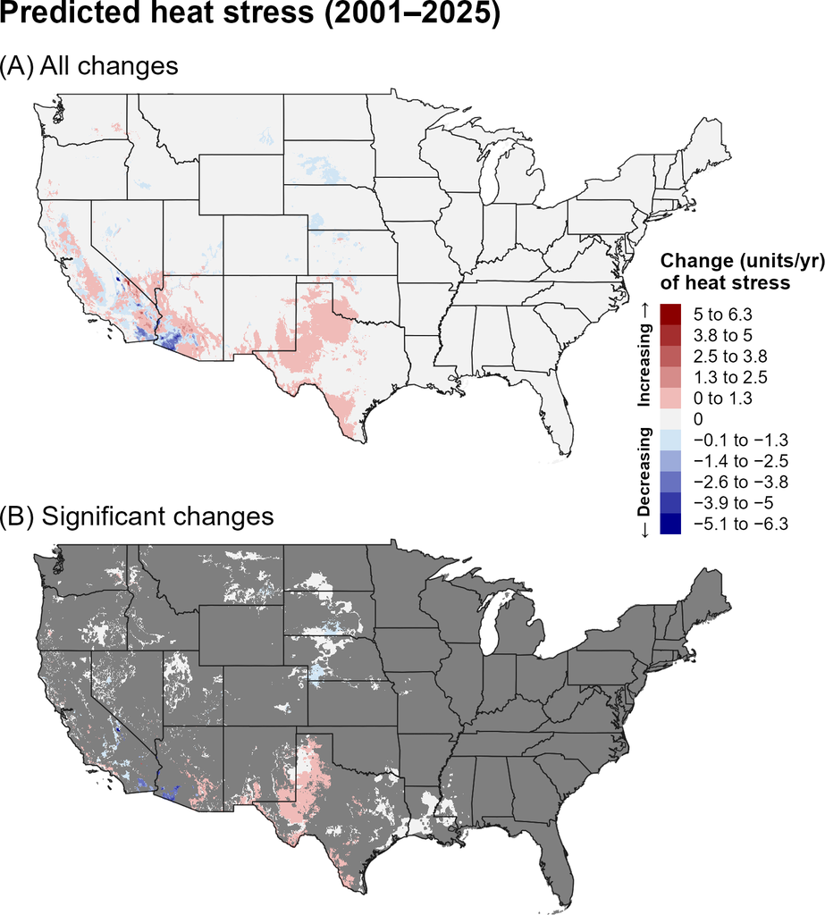

Figure 9: Changes (units/year) in predicted heat stress for SUNP across the CONUS over the recent 24-year period (2001–2025). Maps show (A) all changes and (B) statistically significant changes (P < 0.1); areas shown in gray are not statistically significant. Areas shown as 0 in (B) had significant trends but very small changes.

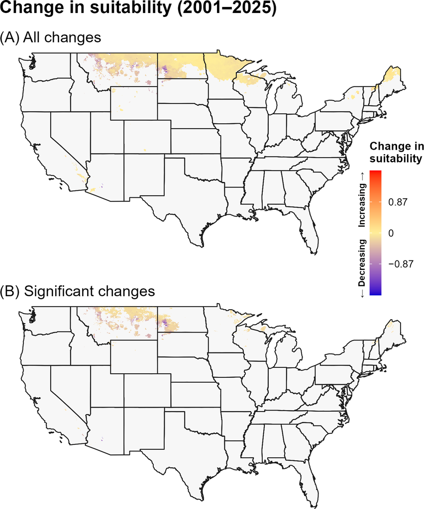

Figure 10: Changes in predicted climatic suitability for SUNP across the CONUS over the recent 24-year period (2001–2025). Suitability is defined as areas not excluded by climate stress. Positive changes (warmer colors) indicate an increased likelihood of establishment, whereas negative changes (cooler colors) indicate a decreased likelihood of establishment.

## **17C. Discussion**

The SUNP maps indicate earlier phenological timing over much of the CONUS during the full period, but a weaker and more heterogeneous pattern during the recent period. Because SUNP development and seasonal movement are closely associated with temperature and seasonal conditions, these shifts could alter the timing of movement and activity in regions where the species can establish.

The long-term increase in predicted suitability across portions of the northern Plains and Great Lakes is consistent with declining cold stress in those regions. Recent increases in cold stress across parts of the same broad region correspond with fewer significant suitability changes, suggesting that the establishment signal has become less consistent during the recent period.

The stronger and more spatially extensive trends in predicted phenology and climate stress over the full 44-year period may reflect both the larger sample size, which can reduce noise and improve detection of directional patterns, and differences in the underlying climate trends between the two time periods. In particular, the recent 24-year period may capture climate variability or regional trends that differ from those observed over the longer 44-year period. Thus, differences between the two periods should be interpreted as reflecting both long-term climate trends and shorter-term regional variability.

## **17D. References**

Aljaryian, R., L. Kumar, and S. Taylor. 2016. Modelling the current and potential future distributions of the Sunn pest *Eurygaster integriceps* (Hemiptera: Scutelleridae) using CLIMEX. Pest Management Science 72:1989–2000.

Banks, C. J., E. S. Brown, and A. Dezfulian. 1961. Field studies of the daily activity and feeding behaviour of Sunn pest, *Eurygaster integriceps* Put., (Hemiptera, Scutelleridae) on wheat in north Iran. Entomologia Experimentalis et Applicata 4:289–300.

Barker, B. S., and L. Coop. 2020. Sunn pest, *Eurygaster integriceps*. Phenology/degree-day and climate suitability white paper for USPEST.ORG. Prepared for United States Department of Agriculture (USDA) – Animal and Plant Health Inspection Service (APHIS) – Plant Protection and Quarantine (PPQ). Vs. 1.0 (8/11/2020). Online at: https://uspest.org/CAPS/Eurygaster_integriceps_white_paper.pdf (accessed 15 December 2025).

Critchley, B. R. 1998. Literature review of sunn pest *Eurygaster integriceps* Put. (Hemiptera, Scutelleridae). Crop Protection 17:271–287.

Davari, A., and B. L. Parker. 2018. A review of research on Sunn Pest {*Eurygaster integriceps* Puton (Hemiptera: Scutelleridae)} management published 2004–2016. Journal of Asia-Pacific Entomology 21:352–360.

EPPO. 2021. *Eurygaster integriceps*. EPPO datasheets on pests recommended for regulation. Online at: https://gd.eppo.int/ (accessed 8 December 2025).

Islamoglu, M. 2022. Effect of some abiotic factors on migration of Sunn pest (*Eurygaster integriceps* Put.) (Hemiptera: Scutelleridae) from aestivation sites to overwintering sites. Pakistan Journal of Zoology 55:379–383.

Kivan, M., and N. Kilic. 2005. Effects of storage at low-temperature of various heteropteran host eggs on the egg parasitoid, Trissolcus semistriatus. BioControl 50:589–600.

Mackesy, D. and H. Moylett. 2018. CPHST Pest Datasheet for *Eurygaster integriceps*. USDA-APHIS-PPQ-CPHST (updated 16 August 2018). Online at: https://caps.ceris.purdue.edu/wp-content/uploads/2025/07/Eurygaster-integriceps-datasheet-final.pdf (accessed 17 September 2026).

Parker, B. L., M. Amir-Maafi, M. Skinner, J. S. Kim, and M. El Bouhssini. 2011. Distribution of Sunn pest, *Eurygaster integriceps* Puton (Hemiptera: Scutelleridae), in overwintering sites. Journal of Asia-Pacific Entomology 14:83–88.

Paulian, F., and C. Popov. 1980. Sunn pest or cereal bug. Wheat Documenta, Technical Monograph. Ciba-Geigy Ltd., Basle, Switzerland.

USDA-NASS. 2019. 2017 Census of Agriculture, Summary and State Data, Volume 1, Geographic Area Series, Part 51. United States Department of Agriculture, National Agriculture Statistics Service.